# A2.3 Modelos de ensamble, SVM y redes neuronales

## 1 Descripcion del problema

En esta actividad se analiza un problema de clasificación supervisada utilizando el conjunto de datos Adult Income disponible en el UCI Machine Learning Repository. Este dataset contiene información demográfica y laboral de individuos recopilada a partir del censo de Estados Unidos.

El objetivo del análisis consiste en predecir si el ingreso anual de una persona supera los 50,000 dólares, utilizando variables socioeconómicas como edad, nivel educativo, tipo de trabajo, estado civil y número de horas trabajadas por semana.

Este problema resulta adecuado para evaluar distintos algoritmos de aprendizaje automático, ya que combina variables numéricas y categóricas y cuenta con un tamaño de muestra suficientemente grande para entrenar modelos más complejos. En particular, se compararán modelos de Random Forest, Boosting, Support Vector Machine y redes neuronales, con el propósito de analizar cuál ofrece el mejor desempeño predictivo.

### 1.1 Variable objetivo

La variable objetivo del modelo es income, que indica si el ingreso anual de la persona es:

- > 50K (ingreso alto)
- ≤50K (ingreso bajo)

Este tipo de variable binaria permite formular el problema como una tarea de clasificación supervisada.

```python
import pandas as pd

url = "https://archive.ics.uci.edu/ml/machine-learning-databases/adult/adult.data"

columns = [
"age","workclass","fnlwgt","education","education_num",
"marital_status","occupation","relationship","race",
"sex","capital_gain","capital_loss","hours_per_week",
"native_country","income"
]

df = pd.read_csv(url, names=columns)

print("Dimensiones del dataset:")
print(df.shape)

print("\nPrimeras filas:")
print(df.head())

print("\nInformación general:")
print(df.info())
```

```
Dimensiones del dataset:
(32561, 15)

Primeras filas:
   age          workclass  fnlwgt   education  education_num  \
0   39          State-gov   77516   Bachelors             13
1   50   Self-emp-not-inc   83311   Bachelors             13
2   38            Private  215646     HS-grad              9
3   53            Private  234721        11th              7
4   28            Private  338409   Bachelors             13

        marital_status          occupation    relationship    race      sex  \
0        Never-married        Adm-clerical   Not-in-family   White     Male
1   Married-civ-spouse     Exec-managerial         Husband   White     Male
2             Divorced   Handlers-cleaners   Not-in-family   White     Male
3   Married-civ-spouse   Handlers-cleaners         Husband   Black     Male
4   Married-civ-spouse      Prof-specialty            Wife   Black   Female

   capital_gain  capital_loss  hours_per_week  native_country  income
0          2174             0              40   United-States   <=50K
1             0             0              13   United-States   <=50K
2             0             0              40   United-States   <=50K
3             0             0              40   United-States   <=50K
4             0             0              40            Cuba   <=50K

Información general:
<class 'pandas.core.frame.DataFrame'>
RangeIndex: 32561 entries, 0 to 32560
Data columns (total 15 columns):
 #   Column          Non-Null Count  Dtype
---  ------          --------------  -----
 0   age             32561 non-null  int64
 1   workclass       32561 non-null  object
 2   fnlwgt          32561 non-null  int64
 3   education       32561 non-null  object
 4   education_num   32561 non-null  int64
 5   marital_status  32561 non-null  object
 6   occupation      32561 non-null  object
 7   relationship    32561 non-null  object
 8   race            32561 non-null  object
 9   sex             32561 non-null  object
 10  capital_gain    32561 non-null  int64
 11  capital_loss    32561 non-null  int64
 12  hours_per_week  32561 non-null  int64
 13  native_country  32561 non-null  object
 14  income          32561 non-null  object
dtypes: int64(6), object(9)
memory usage: 3.7+ MB
None
```

## 2 Limpieza y preparación de datos

Antes de entrenar los modelos de aprendizaje automático, es necesario realizar un proceso de limpieza y preparación de los datos. Este proceso incluye la identificación de valores faltantes, la eliminación o tratamiento de registros incompletos y la transformación de variables categóricas a un formato numérico que pueda ser interpretado por los algoritmos de aprendizaje automático.

En el conjunto de datos Adult Income, algunos valores faltantes están representados por el símbolo "?". Estos registros deben ser tratados adecuadamente para evitar que afecten el desempeño de los modelos.

Posteriormente, se separa la variable objetivo (income) del resto de las variables predictoras. Finalmente, el conjunto de datos se divide en dos subconjuntos: uno para entrenamiento y otro para prueba, lo que permite evaluar el desempeño de los modelos sobre datos que no fueron utilizados durante el entrenamiento.

```python
# Revisar valores faltantes representados como "?"
print("Valores '?' por columna:")
print((df == " ?").sum())
# Reemplazar " ?" por NaN
df = df.replace(" ?", pd.NA)

# Eliminar filas con valores faltantes
df = df.dropna()

print("Nuevo tamaño del dataset:")
print(df.shape)
# Reemplazar " ?" por NaN
df = df.replace(" ?", pd.NA)

# Eliminar filas con valores faltantes
df = df.dropna()

print("Nuevo tamaño del dataset:")
print(df.shape)

# quitar espacios extra en strings
for col in df.select_dtypes(include="object").columns:
    df[col] = df[col].str.strip()

# convertir categóricas a variables dummy
df = pd.get_dummies(df, drop_first=True)

print(df.shape)
```

```
Valores '?' por columna:
age                  0
workclass         1836
fnlwgt               0
education            0
education_num        0
marital_status       0
occupation        1843
relationship         0
race                 0
sex                  0
capital_gain         0
capital_loss         0
hours_per_week       0
native_country     583
income               0
dtype: int64
Nuevo tamaño del dataset:
(30162, 15)
Nuevo tamaño del dataset:
(30162, 15)
(30162, 97)
```

### 2.1 Separar X y Y

```python
# buscar la columna que contiene income
# buscar columna objetivo automáticamente
income_col = [c for c in df.columns if "income" in c][0]

y = df[income_col]
X = df.drop(income_col, axis=1)

print("X:", X.shape)
print("y:", y.shape)
```

```
X: (30162, 96)
y: (30162,)
```

### 2.2 Separar train y test

```python
from sklearn.model_selection import train_test_split

X_train, X_test, y_train, y_test = train_test_split(
    X, y,
    test_size=0.3,
    random_state=42
)

print("Train:", X_train.shape)
print("Test:", X_test.shape)
```

```
Train: (21113, 96)
Test: (9049, 96)
```

## 3. Modelo Random Forest

El primer modelo implementado para resolver el problema de clasificación fue Random Forest, un algoritmo de aprendizaje automático basado en conjuntos (ensemble learning). Este método construye múltiples árboles de decisión durante el entrenamiento y combina sus predicciones para obtener un resultado final más robusto.

Random Forest presenta varias ventajas, entre ellas:

- Reduce el riesgo de overfitting presente en árboles individuales.
- Maneja adecuadamente grandes cantidades de variables.
- Puede capturar relaciones no lineales entre las variables.

En este estudio, el modelo fue entrenado utilizando el conjunto de datos de entrenamiento y posteriormente evaluado sobre el conjunto de prueba para medir su desempeño predictivo.

```python
from sklearn.ensemble import RandomForestClassifier
from sklearn.metrics import accuracy_score

rf = RandomForestClassifier(
    n_estimators=200,
    random_state=42
)

rf.fit(X_train, y_train)

y_pred_rf = rf.predict(X_test)

acc_rf = accuracy_score(y_test, y_pred_rf)

print("Accuracy Random Forest:", acc_rf)
```

```
Accuracy Random Forest: 0.8528014145209415
```

### 3.1 Evaluación del modelo Random Forest

Para evaluar el desempeño del modelo Random Forest se utilizó el conjunto de prueba, el cual contiene observaciones que no fueron utilizadas durante el entrenamiento del modelo. Esto permite medir la capacidad del algoritmo para generalizar a nuevos datos.

El modelo obtuvo una precisión (accuracy) de 0.8528, lo que indica que aproximadamente el 85.28% de las observaciones fueron clasificadas correctamente.

Este resultado sugiere que el modelo es capaz de identificar patrones relevantes entre las variables sociodemográficas y el nivel de ingreso de los individuos. Sin embargo, para comprender mejor el desempeño del modelo es necesario analizar métricas adicionales como la matriz de confusión, la cual permite observar el número de clasificaciones correctas e incorrectas para cada categoría.

#### 3.1.1 Matriz de confusion

```python
from sklearn.metrics import confusion_matrix

cm_rf = confusion_matrix(y_test, y_pred_rf)

print(cm_rf)
```

```
[[6264  503]
 [ 829 1453]]
```

La matriz de confusión permite analizar con mayor detalle el desempeño del modelo, mostrando cuántas observaciones fueron clasificadas correctamente y cuántas fueron clasificadas incorrectamente para cada categoría.

En este caso, el modelo obtuvo los siguientes resultados:

- 6264 verdaderos negativos: personas correctamente clasificadas con ingresos menores o iguales a 50K.
- 1453 verdaderos positivos: personas correctamente clasificadas con ingresos mayores a 50K.
- 503 falsos positivos: personas clasificadas incorrectamente como ingreso alto.
- 829 falsos negativos: personas clasificadas incorrectamente como ingreso bajo.

Estos resultados muestran que el modelo presenta un buen desempeño general, aunque se observa que la clase correspondiente a ingresos mayores a 50K resulta más difícil de predecir correctamente.

### 3.1.2 Classification report

```python
from sklearn.metrics import classification_report

print(classification_report(y_test, y_pred_rf))
```

```
              precision    recall  f1-score   support

       False       0.88      0.93      0.90      6767
        True       0.74      0.64      0.69      2282

    accuracy                           0.85      9049
   macro avg       0.81      0.78      0.79      9049
weighted avg       0.85      0.85      0.85      9049
```

El classification report permite analizar métricas adicionales como precision, recall y F1-score.

Los resultados obtenidos muestran:

Clase ≤50K

- Precision: 0.88
- Recall: 0.93
- F1-score: 0.90

Clase >50K

- Precision: 0.74
- Recall: 0.64
- F1-score: 0.69

Esto indica que el modelo identifica con mayor facilidad los casos de ingresos menores a 50K, mientras que presenta mayor dificultad para detectar correctamente los casos de ingresos superiores a 50K. Esto es común en problemas de clasificación donde existe cierto desbalance entre las clases.

En términos generales, el modelo alcanzó una accuracy de 0.85, lo que confirma un desempeño sólido para este problema.

### 3.1.3 Importancia de variables

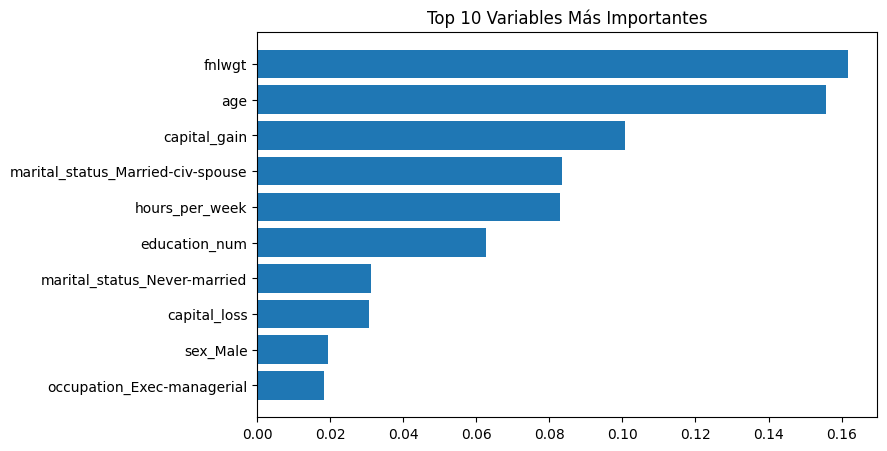

```python
import pandas as pd
import matplotlib.pyplot as plt

importances = rf.feature_importances_

features = X.columns

importance_df = pd.DataFrame({
    "feature": features,
    "importance": importances
})

importance_df = importance_df.sort_values("importance", ascending=False).head(10)

plt.figure(figsize=(8,5))
plt.barh(importance_df["feature"], importance_df["importance"])
plt.gca().invert_yaxis()
plt.title("Top 10 Variables Más Importantes")
plt.show()
```

Una ventaja importante del algoritmo Random Forest es que permite estimar la importancia relativa de cada variable en el proceso de clasificación.

Los resultados muestran que las variables más influyentes para predecir el nivel de ingreso fueron:

- fnlwgt
- age
- capital_gain
- marital_status
- hours_per_week
- education_num

Esto sugiere que factores como la edad, el nivel educativo, el estado civil y las horas trabajadas por semana influyen significativamente en la probabilidad de que una persona tenga ingresos superiores a 50K.

### 3.1.4 Curva ROC

Para evaluar la capacidad del modelo para discriminar entre las dos clases, se utilizó la curva ROC (Receiver Operating Characteristic). Esta gráfica representa la relación entre la tasa de verdaderos positivos (TPR) y la tasa de falsos positivos (FPR) para distintos umbrales de clasificación.

El modelo Random Forest obtuvo un Área Bajo la Curva (AUC) de 0.904, lo que indica una excelente capacidad de discriminación entre las clases. Esto significa que el modelo tiene una alta probabilidad de asignar correctamente una mayor probabilidad a los individuos con ingresos superiores a 50K en comparación con aquellos con ingresos menores.

La forma de la curva ROC confirma que el modelo logra una alta tasa de verdaderos positivos manteniendo una tasa relativamente baja de falsos positivos.

```
AUC Random Forest: 0.90402769821634
```

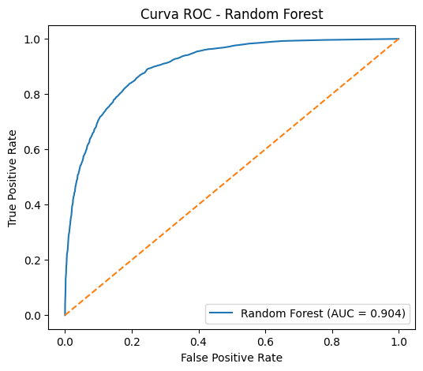

```python
from sklearn.metrics import roc_curve, roc_auc_score
import matplotlib.pyplot as plt

# Probabilidades de la clase positiva
y_prob_rf = rf.predict_proba(X_test)[:,1]

# Calcular curva ROC
fpr, tpr, thresholds = roc_curve(y_test, y_prob_rf)

# Calcular AUC
auc_rf = roc_auc_score(y_test, y_prob_rf)

print("AUC Random Forest:", auc_rf)

# Graficar
plt.figure(figsize=(6,5))
plt.plot(fpr, tpr, label=f"Random Forest (AUC = {auc_rf:.3f})")
plt.plot([0,1],[0,1], linestyle="--")
plt.xlabel("False Positive Rate")
plt.ylabel("True Positive Rate")
plt.title("Curva ROC - Random Forest")
plt.legend()
plt.show()
```

## 4 Support Vector Machine (SVM)

El segundo modelo implementado fue Support Vector Machine (SVM), un algoritmo de aprendizaje supervisado ampliamente utilizado para problemas de clasificación. Este modelo busca encontrar el hiperplano que mejor separa las clases en el espacio de características, maximizando la distancia entre los puntos de datos más cercanos de cada clase, conocidos como vectores de soporte.

Para este análisis se utilizó un kernel radial (RBF), el cual permite capturar relaciones no lineales entre las variables. Antes de entrenar el modelo, se realizó un proceso de escalamiento de las variables, ya que SVM es sensible a las diferencias de escala entre las características.

```python
from sklearn.preprocessing import StandardScaler

scaler = StandardScaler()

X_train_scaled = scaler.fit_transform(X_train)
X_test_scaled = scaler.transform(X_test)
```

### 4.1 Entrenar SVM

```python
from sklearn.svm import SVC
from sklearn.metrics import accuracy_score

svm = SVC(kernel="rbf")

svm.fit(X_train_scaled, y_train)

y_pred_svm = svm.predict(X_test_scaled)

acc_svm = accuracy_score(y_test, y_pred_svm)

print("Accuracy SVM:", acc_svm)
```

```
Accuracy SVM: 0.8461708476074704
```

### 4.2 Evaluacion del modelo SVM

### 4.2.1 Matriz de confusion

La matriz de confusión permite analizar el desempeño del modelo SVM en términos de clasificaciones correctas e incorrectas para cada clase.

Los resultados obtenidos fueron:

- 6352 verdaderos negativos: individuos correctamente clasificados con ingresos menores o iguales a 50K.
- 1305 verdaderos positivos: individuos correctamente clasificados con ingresos superiores a 50K.
- 415 falsos positivos: individuos clasificados incorrectamente como ingresos mayores a 50K.
- 977 falsos negativos: individuos clasificados incorrectamente como ingresos menores a 50K.

Estos resultados muestran que el modelo tiene un buen desempeño para identificar la clase de ingresos menores o iguales a 50K, aunque presenta mayor dificultad para detectar correctamente los casos de ingresos superiores a 50K.

```python
from sklearn.metrics import confusion_matrix

cm_svm = confusion_matrix(y_test, y_pred_svm)

print(cm_svm)
```

```
[[6352  415]
 [ 977 1305]]
```

### 4.2.2 Classification Report

El classification report muestra métricas más detalladas del desempeño del modelo.

Para la clase ≤50K el modelo obtuvo:

- Precision: 0.87
- Recall: 0.94
- F1-score: 0.90

Para la clase >50K:

- Precision: 0.76
- Recall: 0.57
- F1-score: 0.65

Esto indica que el modelo logra identificar correctamente la mayoría de los individuos con ingresos menores a 50K, pero presenta mayor dificultad para detectar los casos de ingresos superiores, lo cual puede deberse al desbalance existente entre las clases en el conjunto de datos.

El modelo alcanzó una accuracy general de aproximadamente 0.85, lo cual representa un desempeño competitivo para este problema de clasificación.

```python
from sklearn.metrics import classification_report

print(classification_report(y_test, y_pred_svm))
```

```
              precision    recall  f1-score   support

       False       0.87      0.94      0.90      6767
        True       0.76      0.57      0.65      2282

    accuracy                           0.85      9049
   macro avg       0.81      0.76      0.78      9049
weighted avg       0.84      0.85      0.84      9049
```

### 4.2.3 Curva ROC

La curva ROC obtenida para el modelo SVM muestra la relación entre la tasa de verdaderos positivos y la tasa de falsos positivos a distintos umbrales de clasificación.

El modelo obtuvo un Área Bajo la Curva (AUC) de 0.893, lo cual indica una muy buena capacidad de discriminación entre las clases. Aunque este valor es ligeramente inferior al obtenido por Random Forest (AUC = 0.904), el desempeño sigue siendo alto y confirma que el modelo SVM es capaz de identificar patrones relevantes en los datos.

```
AUC SVM: 0.893386565493443
```

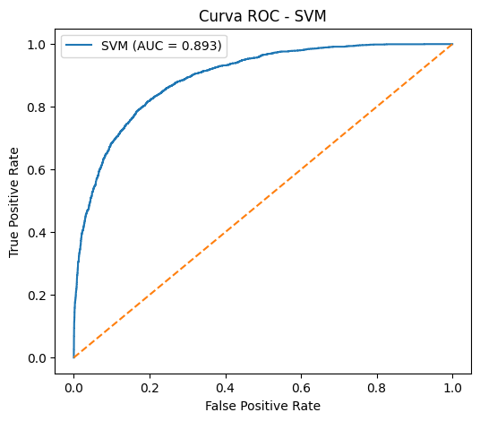

```python
from sklearn.svm import SVC

svm = SVC(kernel="rbf", probability=True)

svm.fit(X_train_scaled, y_train)

y_prob_svm = svm.predict_proba(X_test_scaled)[:,1]

from sklearn.metrics import roc_curve, roc_auc_score
import matplotlib.pyplot as plt

fpr_svm, tpr_svm, _ = roc_curve(y_test, y_prob_svm)

auc_svm = roc_auc_score(y_test, y_prob_svm)

print("AUC SVM:", auc_svm)

plt.figure(figsize=(6,5))
plt.plot(fpr_svm, tpr_svm, label=f"SVM (AUC = {auc_svm:.3f})")
plt.plot([0,1],[0,1],'--')
plt.xlabel("False Positive Rate")
plt.ylabel("True Positive Rate")
plt.title("Curva ROC - SVM")
plt.legend()
plt.show()
```

## 5. Gradient Boosting

El siguiente modelo implementado fue Gradient Boosting, un método de aprendizaje basado en conjuntos (ensemble learning) que construye modelos secuenciales donde cada nuevo modelo intenta corregir los errores cometidos por los anteriores.

A diferencia de Random Forest, donde los árboles se construyen de manera independiente, en Gradient Boosting los árboles se construyen de forma secuencial, lo que permite mejorar progresivamente el desempeño del modelo.

Este enfoque suele ofrecer un alto rendimiento en problemas de clasificación tabular como el presente.

```python
from sklearn.ensemble import GradientBoostingClassifier
from sklearn.metrics import accuracy_score

gb = GradientBoostingClassifier(
    n_estimators=200,
    learning_rate=0.05,
    random_state=42
)

gb.fit(X_train, y_train)

y_pred_gb = gb.predict(X_test)

acc_gb = accuracy_score(y_test, y_pred_gb)

print("Accuracy Gradient Boosting:", acc_gb)
```

```
Accuracy Gradient Boosting: 0.8634103215824953
```

### 5.1 Evaluación del modelo Gradient Boosting

El modelo Gradient Boosting fue evaluado utilizando el conjunto de prueba para analizar su capacidad de generalización. Los resultados obtenidos muestran que el modelo alcanzó una accuracy de 0.863, lo que indica que aproximadamente 86.3% de las observaciones fueron clasificadas correctamente.

Este resultado representa una mejora respecto a los modelos previamente evaluados (Random Forest y SVM), lo cual sugiere que el enfoque secuencial utilizado por Gradient Boosting permite capturar de manera más efectiva los patrones presentes en los datos.

### 5.1.2 Matriz de confusion

La matriz de confusión permite analizar el desempeño del modelo Gradient Boosting en términos de clasificaciones correctas e incorrectas para cada clase.

Los resultados obtenidos fueron:

- 6427 verdaderos negativos: individuos correctamente clasificados con ingresos menores o iguales a 50K.
- 1386 verdaderos positivos: individuos correctamente clasificados con ingresos superiores a 50K.
- 340 falsos positivos: individuos clasificados incorrectamente como ingresos superiores a 50K.
- 896 falsos negativos: individuos clasificados incorrectamente como ingresos menores a 50K.

Estos resultados muestran que el modelo tiene un buen desempeño para identificar ambas clases, aunque todavía presenta mayor dificultad para detectar correctamente todos los casos de ingresos superiores a 50K.

```python
from sklearn.metrics import confusion_matrix

cm_gb = confusion_matrix(y_test, y_pred_gb)

print(cm_gb)
```

```
[[6427  340]
 [ 896 1386]]
```

### 5.1.3 Classification Report

El classification report muestra métricas más detalladas del desempeño del modelo.

Para la clase ≤50K:

- Precision: 0.88
- Recall: 0.95
- F1-score: 0.91

Para la clase >50K:

- Precision: 0.80
- Recall: 0.61
- F1-score: 0.69

El modelo obtuvo una accuracy general de 0.863, lo cual representa el mejor desempeño entre los modelos evaluados hasta este punto.

```python
from sklearn.metrics import classification_report

print(classification_report(y_test, y_pred_gb))
```

```
              precision    recall  f1-score   support

       False       0.88      0.95      0.91      6767
        True       0.80      0.61      0.69      2282

    accuracy                           0.86      9049
   macro avg       0.84      0.78      0.80      9049
weighted avg       0.86      0.86      0.86      9049
```

### 5.1.4 Curva ROC

La curva ROC obtenida para el modelo Gradient Boosting muestra la relación entre la tasa de verdaderos positivos y la tasa de falsos positivos para distintos umbrales de clasificación.

El modelo obtuvo un Área Bajo la Curva (AUC) de 0.919, lo que indica una excelente capacidad de discriminación entre las clases. Este valor es superior al obtenido por los modelos Random Forest (AUC = 0.904) y SVM (AUC = 0.893), lo que confirma que Gradient Boosting ofrece el mejor desempeño en este conjunto de datos.

```
AUC Gradient Boosting: 0.9194776371956135
```

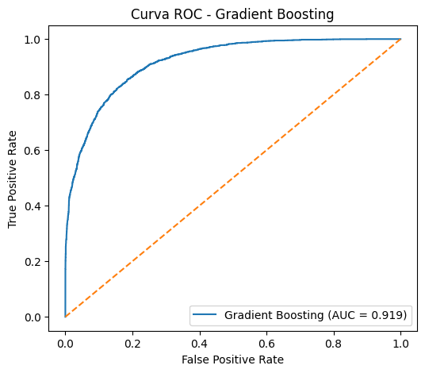

```python
from sklearn.metrics import roc_curve, roc_auc_score
import matplotlib.pyplot as plt

y_prob_gb = gb.predict_proba(X_test)[:,1]

fpr_gb, tpr_gb, _ = roc_curve(y_test, y_prob_gb)

auc_gb = roc_auc_score(y_test, y_prob_gb)

print("AUC Gradient Boosting:", auc_gb)

plt.figure(figsize=(6,5))
plt.plot(fpr_gb, tpr_gb, label=f"Gradient Boosting (AUC = {auc_gb:.3f})")
plt.plot([0,1],[0,1],'--')
plt.xlabel("False Positive Rate")
plt.ylabel("True Positive Rate")
plt.title("Curva ROC - Gradient Boosting")
plt.legend()
plt.show()
```

## 6. Red neuronal

El último modelo evaluado fue una red neuronal artificial implementada con Keras. Este tipo de modelo permite aprender relaciones no lineales entre las variables mediante capas de neuronas interconectadas.

Debido a que las redes neuronales son sensibles a la escala de los datos, se utilizaron las variables previamente estandarizadas. El modelo fue entrenado con el conjunto de entrenamiento y posteriormente evaluado con el conjunto de prueba.

```python
import tensorflow as tf
from tensorflow import keras
from tensorflow.keras import layers
from sklearn.metrics import accuracy_score

tf.random.set_seed(42)

model = keras.Sequential([
    layers.Dense(32, activation='relu', input_shape=(X_train_scaled.shape[1],)),
    layers.Dense(16, activation='relu'),
    layers.Dense(1, activation='sigmoid')
])

model.compile(
    optimizer='adam',
    loss='binary_crossentropy',
    metrics=['accuracy']
)

history = model.fit(
    X_train_scaled, y_train,
    epochs=20,
    batch_size=32,
    validation_split=0.2,
    verbose=1
)

import numpy as np

y_prob_nn = model.predict(X_test_scaled).ravel()
y_pred_nn = (y_prob_nn > 0.5).astype(int)

acc_nn = accuracy_score(y_test, y_pred_nn)

print("Accuracy Red Neuronal (Keras):", acc_nn)
```

```
Accuracy Red Neuronal (Keras): 0.8467233948502597
```

### 6.1 Evaluación de la red neuronal

La red neuronal implementada mediante Keras fue evaluada utilizando el conjunto de prueba para analizar su capacidad de generalización. Los resultados muestran que el modelo obtuvo una accuracy de 0.8467, lo que indica que aproximadamente 84.7% de las observaciones fueron clasificadas correctamente.

Este resultado es comparable al obtenido con el modelo SVM, lo que sugiere que ambos algoritmos logran capturar patrones similares en los datos. Sin embargo, el modelo Gradient Boosting continúa mostrando el mejor desempeño entre los modelos evaluados.

#### 6.1.1 Matriz de confusion

La matriz de confusión permite analizar el desempeño del modelo de red neuronal en términos de clasificaciones correctas e incorrectas para cada clase.

Los resultados obtenidos fueron:

- 6203 verdaderos negativos: individuos correctamente clasificados con ingresos menores o iguales a 50K.
- 1459 verdaderos positivos: individuos correctamente clasificados con ingresos superiores a 50K.
- 564 falsos positivos: individuos clasificados incorrectamente como ingresos superiores a 50K.
- 823 falsos negativos: individuos clasificados incorrectamente como ingresos menores a 50K.

Estos resultados muestran que el modelo logra identificar correctamente una gran proporción de individuos con ingresos menores a 50K, aunque todavía presenta cierta dificultad para detectar todos los casos de ingresos superiores.

```python
from sklearn.metrics import confusion_matrix

cm_nn = confusion_matrix(y_test, y_pred_nn)
print(cm_nn)
```

```
[[6203  564]
 [ 823 1459]]
```

#### 6.1.2 Classification Report

El classification report muestra métricas adicionales que permiten evaluar con mayor detalle el desempeño del modelo.

Para la clase ≤50K:

- Precision: 0.88
- Recall: 0.92
- F1-score: 0.90

Para la clase >50K:

- Precision: 0.72
- Recall: 0.64
- F1-score: 0.68

El modelo alcanzó una accuracy general de aproximadamente 0.847, lo que indica un desempeño competitivo en el problema de clasificación.

```python
from sklearn.metrics import classification_report

print(classification_report(y_test, y_pred_nn))
```

```
              precision    recall  f1-score   support

       False       0.88      0.92      0.90      6767
        True       0.72      0.64      0.68      2282

    accuracy                           0.85      9049
   macro avg       0.80      0.78      0.79      9049
weighted avg       0.84      0.85      0.84      9049
```

#### 6.1.3 Curva ROC

La curva ROC obtenida para la red neuronal muestra la relación entre la tasa de verdaderos positivos y la tasa de falsos positivos a diferentes umbrales de clasificación.

El modelo obtuvo un Área Bajo la Curva (AUC) de 0.899, lo que indica una muy buena capacidad de discriminación entre las clases. Este valor es comparable al obtenido por Random Forest y SVM, aunque ligeramente inferior al obtenido por Gradient Boosting.

```
AUC Red Neuronal: 0.8987410808264628
```

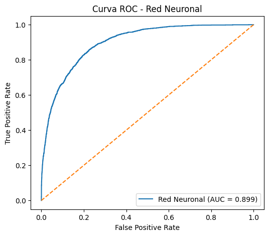

```python
from sklearn.metrics import roc_curve, roc_auc_score
import matplotlib.pyplot as plt

fpr_nn, tpr_nn, _ = roc_curve(y_test, y_prob_nn)
auc_nn = roc_auc_score(y_test, y_prob_nn)

print("AUC Red Neuronal:", auc_nn)

plt.figure(figsize=(6,5))
plt.plot(fpr_nn, tpr_nn, label=f"Red Neuronal (AUC = {auc_nn:.3f})")
plt.plot([0,1],[0,1],'--')
plt.xlabel("False Positive Rate")
plt.ylabel("True Positive Rate")
plt.title("Curva ROC - Red Neuronal")
plt.legend()
plt.show()
```

## 7. Evaluacion y comparacion de desempeño

En este estudio se evaluaron cuatro modelos de aprendizaje automático con el objetivo de predecir si el ingreso anual de una persona supera los 50,000 dólares. Los modelos analizados fueron Random Forest, Support Vector Machine (SVM), Gradient Boosting y una red neuronal implementada con Keras. Cada modelo fue entrenado utilizando el conjunto de entrenamiento y posteriormente evaluado con el conjunto de prueba para comparar su desempeño.

La gráfica muestra la comparación del accuracy obtenido por cada modelo. El eje horizontal representa los distintos algoritmos evaluados, mientras que el eje vertical muestra el valor de accuracy obtenido en el conjunto de prueba.

A partir de esta visualización se puede observar que Gradient Boosting obtuvo el mayor nivel de precisión, alcanzando aproximadamente un 86.3% de clasificaciones correctas, lo que lo convierte en el modelo con mejor desempeño entre los evaluados. Esto se debe a que este algoritmo construye los árboles de decisión de manera secuencial, permitiendo que cada nuevo modelo corrija los errores cometidos por los anteriores.

Por otro lado, Random Forest también mostró un desempeño sólido, con un accuracy cercano al 85%. Este modelo es robusto debido a que combina múltiples árboles de decisión entrenados de manera independiente, reduciendo el riesgo de sobreajuste y mejorando la estabilidad de las predicciones.

Los modelos SVM y la red neuronal presentaron resultados ligeramente inferiores, aunque aún competitivos. Ambos algoritmos alcanzaron valores de accuracy cercanos al 84–85%, lo que indica que también logran capturar patrones relevantes dentro del conjunto de datos.

En general, las diferencias observadas entre los modelos son moderadas, lo que sugiere que el problema de clasificación puede ser abordado de manera efectiva por distintos enfoques de aprendizaje automático. Sin embargo, los modelos basados en ensemble learning, particularmente Gradient Boosting, demostraron una ligera ventaja en términos de desempeño predictivo.

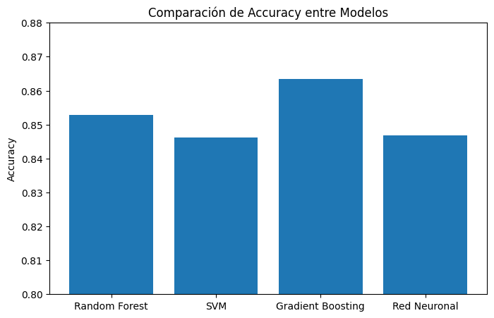

```python
import matplotlib.pyplot as plt

modelos = ["Random Forest", "SVM", "Gradient Boosting", "Red Neuronal"]

accuracy = [
    acc_rf,
    acc_svm,
    acc_gb,
    acc_nn
]

plt.figure(figsize=(8,5))
plt.bar(modelos, accuracy)

plt.title("Comparación de Accuracy entre Modelos")
plt.ylabel("Accuracy")
plt.ylim(0.80, 0.88)

plt.show()
```

## 8. Análisis crítico y conclusiones

Los resultados obtenidos permiten realizar una reflexión sobre el comportamiento de los distintos modelos de aprendizaje automático evaluados. En general, todos los algoritmos lograron un desempeño relativamente alto en la tarea de clasificación, con valores de accuracy superiores al 84%. Esto indica que el conjunto de datos contiene patrones claros que pueden ser identificados por diferentes enfoques de modelado.

Entre los modelos evaluados, Gradient Boosting obtuvo el mejor desempeño, tanto en términos de accuracy como en el área bajo la curva ROC. Esto sugiere que el enfoque secuencial utilizado por este algoritmo, en el que cada nuevo árbol se entrena para corregir los errores de los anteriores, permite capturar de manera más precisa las relaciones presentes en los datos. Sin embargo, la mejora observada respecto a otros modelos no fue extremadamente grande, lo que indica que el problema puede ser abordado de forma efectiva por distintos tipos de algoritmos.

Un aspecto importante a considerar es la relación entre complejidad del modelo y mejora en el desempeño. Aunque Gradient Boosting presentó los mejores resultados, modelos como Random Forest lograron un rendimiento muy cercano utilizando una estructura más sencilla y con menor riesgo de sobreajuste. Esto demuestra que en algunos casos aumentar la complejidad del modelo no necesariamente produce mejoras drásticas en el desempeño.

Otro punto relevante es el riesgo de sobreajuste (overfitting). Los modelos más complejos, especialmente las redes neuronales y los métodos basados en boosting, pueden adaptarse demasiado a los datos de entrenamiento si no se controlan adecuadamente sus parámetros. En este análisis no se observaron indicios claros de sobreajuste, pero en aplicaciones reales sería recomendable utilizar técnicas adicionales de validación para garantizar que el modelo generalice correctamente a nuevos datos.

También es importante considerar la interpretabilidad de los modelos. Algoritmos como Random Forest permiten analizar la importancia de las variables, lo que facilita comprender qué factores influyen en las predicciones del modelo. En contraste, las redes neuronales tienden a ser menos interpretables, ya que su funcionamiento interno es más complejo y difícil de explicar.

Finalmente, la elección del modelo más adecuado depende del contexto de aplicación. Si el objetivo principal es maximizar el desempeño predictivo, Gradient Boosting representa una opción muy sólida. Sin embargo, si se requiere mayor interpretabilidad o menor complejidad computacional, modelos como Random Forest o incluso SVM pueden ser alternativas adecuadas.

En conclusión, este análisis demuestra que diferentes enfoques de aprendizaje automático pueden ofrecer resultados competitivos en problemas de clasificación tabular. La selección final del modelo debe considerar no solo las métricas de desempeño, sino también aspectos como la interpretabilidad, la complejidad del modelo y las necesidades específicas del problema que se desea resolver.

#### Referencias

- Dua, D., & Graff, C. (2019). UCI Machine Learning Repository [Base de datos]. University of California, Irvine, School of Information and Computer Sciences. https://archive.ics.uci.edu/ml/datasets/adult

#### Codigo de honor

"Doy mi palabra que he realizado esta actividad con integridad academica" Emiliano Q.